# AGUA Y SALUD

11/12/2021

**AGUA Y SALUD**

*¿POR QUE?*

El agua representa el elemento primordial de toda la vida del planeta porque comprende la estructura y funcionalidad de las celulas.

El cuerpo humano esta formado en un 60% por agua.

[figure not shown]

## AGUA

- Humano promedio
  - Consume 2.3 litros/agua/dia
  - Expele 2.3 litros/agua/dia
- Dependencia hídrica:
  - perdida 1%: sed
  - perdida 5%: fiebre
  - perdida 10%: inmovilidad
  - perdida 12%: muerte

[figure not shown]

## Principales Objetivos

1. Relacionar diferentes zonas geograficas con los distintos niveles de calidad de agua.
2. Deteccion de enfermedades en aguas residuales.
3. Grafica de Castilla y Leon segun la calidad del agua de consumo y baño.

[figure not shown]

## METODOLOGIA

- Los archivos escogidos pertenecen a la pagina oficial de la Junta de Castilla y Leon
- El formato de los datos escogidos son de extension .csv
- Ficheros:
  - Calificacion de zonas de baño
  - [Analisis de aguas residuales](https://analisis.datosabiertos.jcyl.es/explore/dataset/analisis-aguas-residuales-covid/information/?disjunctive.edar&disjunctive.resultado_sars_cov_2&sort=fecha_recogida_muestra)
  - [Calificación de agua por provincias](https://analisis.datosabiertos.jcyl.es/explore/dataset/calidad-de-las-aguas-de-consumo-humano/information/?disjunctive.ano&disjunctive.provincia)

[figure not shown]

## Analisis

Nuestro set de datos [Calificación de agua por provincias](https://analisis.datosabiertos.jcyl.es/explore/dataset/calidad-de-las-aguas-de-consumo-humano/information/?disjunctive.ano&disjunctive.provincia), esta formado por 50 columnas, de las cuales nos centramos en Año, Provincia y las 5 diferentes columnas segun la calidad del agua.

- Año: Indica en que fecha han sido recogidas las muestras
- Provincias: Indica en que lugar han sido recogidas las muestras

## Analisis

- Apta para el consumo: Nº boletines analíticos de calidad de aguas de consumo humano apta para el consumo
- Apta para el consumo con no conformidad: Nº boletines analíticos de calidad de aguas de consumo humano apta para el consumo con no conformidad
- No apta para el consumo: Nº boletines analíticos de calidad de aguas de consumo humano no apta para el consumo
- No apta para el consumo con riesgo para la salud: Nº boletines analíticos de calidad de aguas de consumo humano No apta para el consumo con riesgo para la salud
- Análisis sin calificación: Nº boletines analíticos de calidad de aguas de consumo humano sin calificación

## Analisis

Nuestro set de datos [Analisis de aguas residuales](https://analisis.datosabiertos.jcyl.es/explore/dataset/analisis-aguas-residuales-covid/information/?disjunctive.edar&disjunctive.resultado_sars_cov_2&sort=fecha_recogida_muestra), esta formado por 5 columnas, de las cuales nos centramos en Fecha de recogida, Edar, Resultados y Variacion.

- Fecha de recogida: Indica en que fecha han sido recogidas las muestras
- Edar: Indica en que lugar han sido recogidas las muestras
- Resultados: Indica si el analisis ha resultado positivo o negativo
- Variacion: Indica si ha habido un aumento o disminucion respecto a la muestra recogida anteriormente

## Analisis

Nuestro set de datos Calificacion de zonas de baño, esta formado por un total de 28 columnas en la que nos centraremos en las columnas de Año, Provincia y Calificación.

- Año: Indica el año de cuando fueron tomados los valores(2020-2010)
- Provincia: Indica la provincia de CyL a la que pertenecen los datos
- Calificación: califica el agua con distintos valores, EXCELENTE, BUENA, SUFICIENTE, INSUFICIENTE y SIN CALIFICAR

## OBJETIVO 1

En el primer obetivo hablaremos sobre las diferentes provincias de **Castilla y León** y sus distintas calidades de agua, con tres niveles de calidad de agua, **apta**, **no apta** y **sin calificar**. Lo haremos para los años **2019**, **2018**, **2017** y **2016**.

[figure not shown]

## OBJETIVO 1

Para relacionar las diferentes calidades de agua con sus respectivas provincias de Castilla y León en los distintos años mencionados anteriormente, hemos tenido que reagrupar columnas de la base de datos puesto que en ella encontrabamos las calidades de agua separadas en dos tipos de aptos y no aptos, lo cual no nos parecia extremadamente relevante para nuestro analisis por lo que hemos optado por reagrupar las calidades de agua en apto y no apto, además de sin calificar.

[figure not shown]

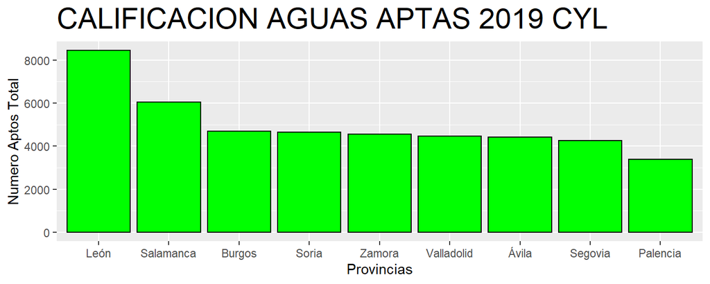

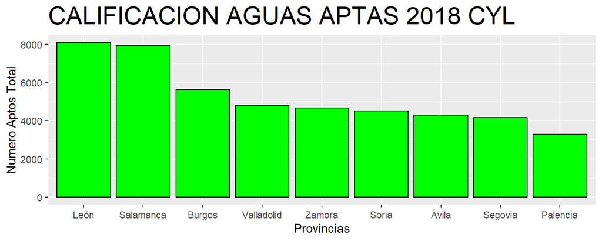

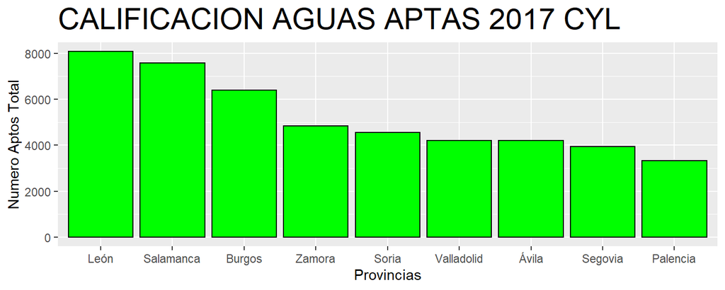

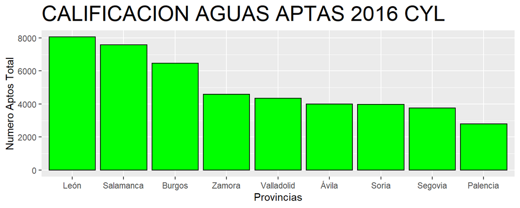

Podemos observar como a la cabeza de Castilla y León en terminos de calidad a agua encontramos en primer lugar a León durante 4 años consecutivos al igual que en segundo lugar se encuentra Salamanca y en tercer lugar Burgos durante estos 4 años. El resto de provincias tienen niveles mas o menos parecidos y campian de posicion dependiendo de los años salvo Segovia y palencia que siempre estan en último lugar.

[figure not shown]

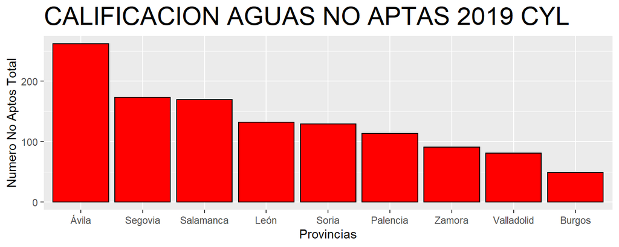

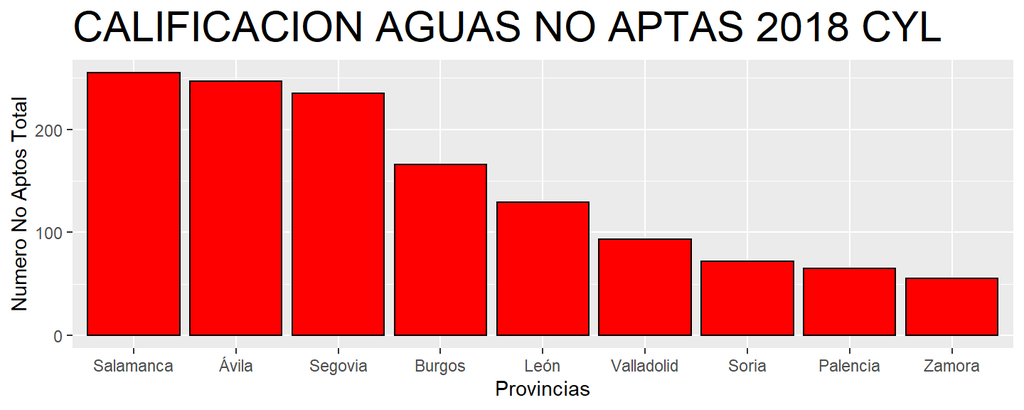

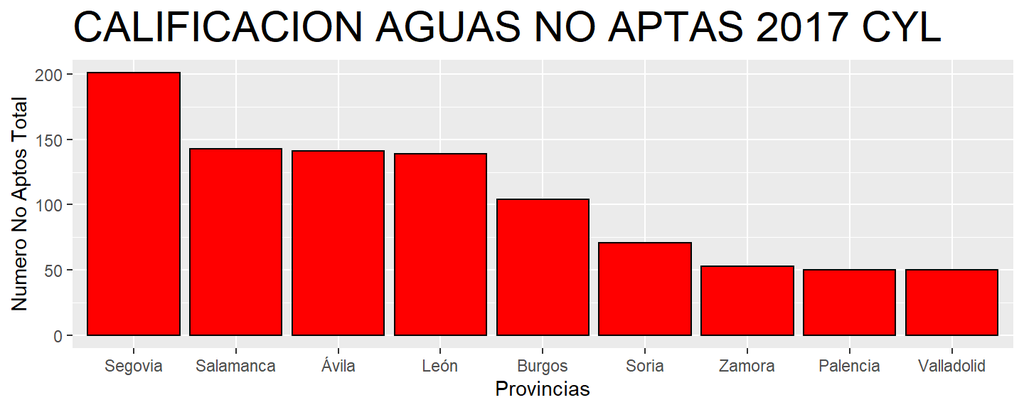

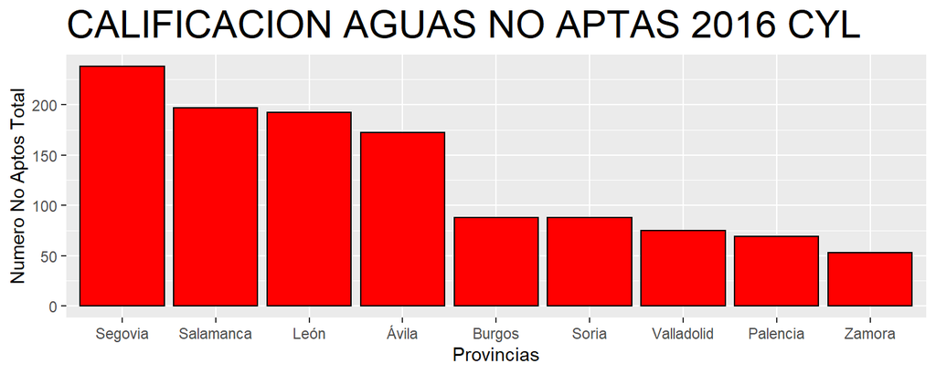

Podemos observar como en cuanto a calidad del agua no apta no podemos establecer ninguna relacion clara entre provincias ya que estas varian ampliamente durante los 4 años de nuestro estudio. No obstante, podriamos remarcar que Ávila, Segovia y salamaca se pelean por las tres primeras plazas en cuanto a calidad del agua no apta, salvo en 2016 donde entra en juego tambíen León. Podríamos recalcar también que Palencia y zamora se encuentran casi siempre en las ultimas posiciones.

[figure not shown]

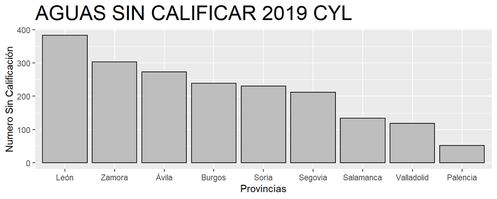

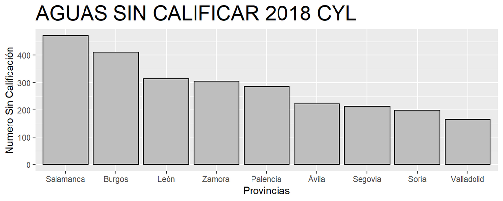

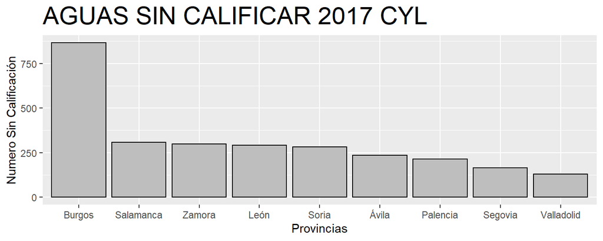

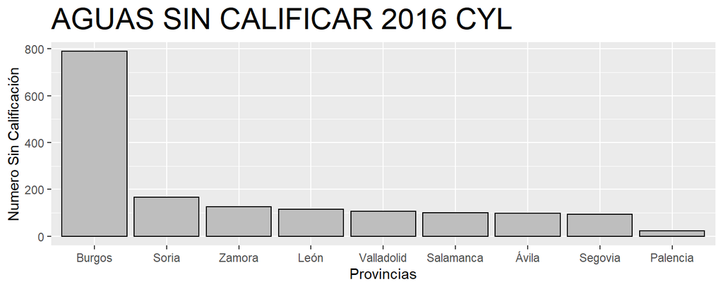

Para terminar con el objetivo 1, podemos observar que no existe relación alguna entre las provincias y sus niveles de agua sin calificar.

[figure not shown]

## OBJETIVO 2

En este segundo objetivo hableremos sobre la deteccion de enfermedades analizando las aguas residuales. En la situacion en la que nos encontramos, se ha hecho patente que el analisis de las aguas residuales nos puede ayudar para localizar e incluso predecir un futuro brote de alguna enfermedad. En este caso, se busca la presencia de **COVID-19** en las aguas residuales de **Castilla y León** y su evolucion.

[figure not shown]

## OBJETIVO 2

[figure not shown]

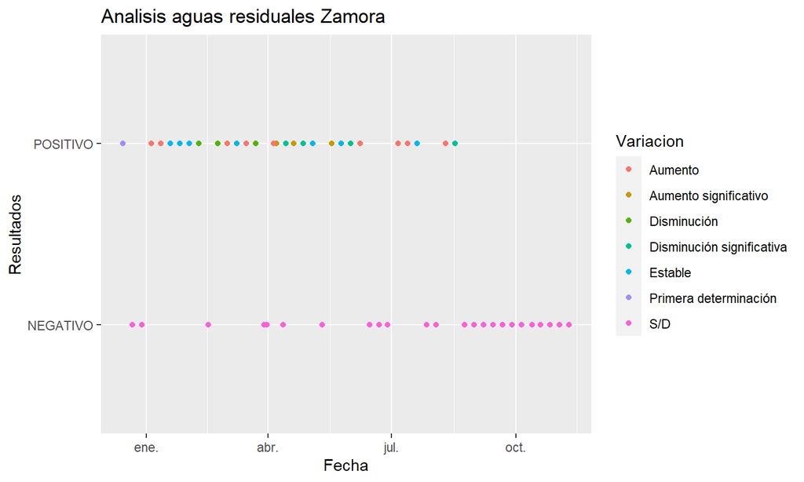

Podemos observar como se detecta el primer positivo a finales de 2020 y se sigue detectando valores positivos a lo largo del año. Pero a partir de septiembre no se detectan nuevos positivos, lo que nos indica que la provincia esta en muy buena situacion.

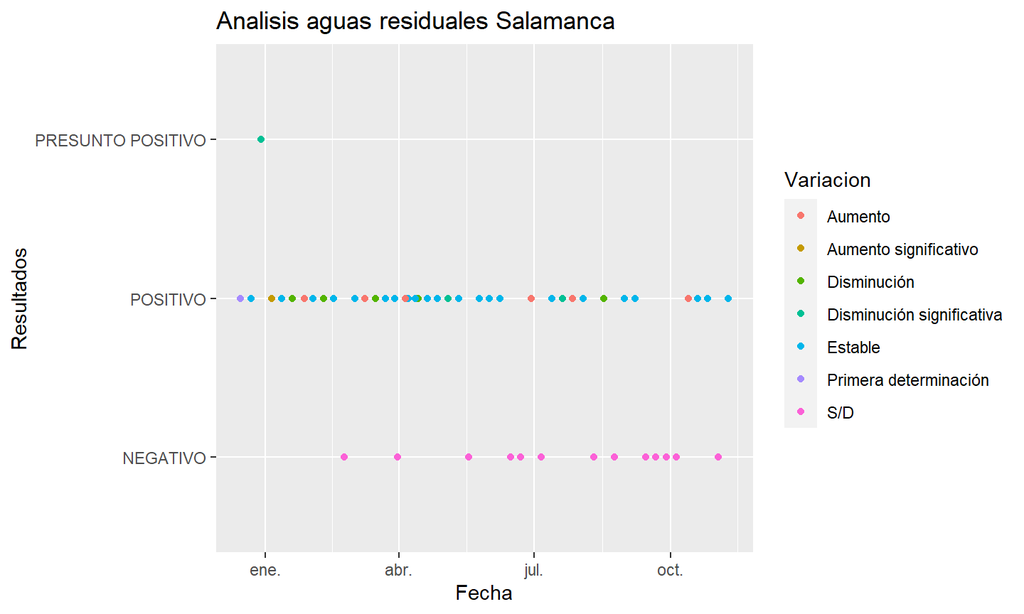

En Salamanca observamos como se ha detectado la presencia del COVID-19 regularmente durante todo el año. Observamos la cantidad se matiene constante a lo largo del año.

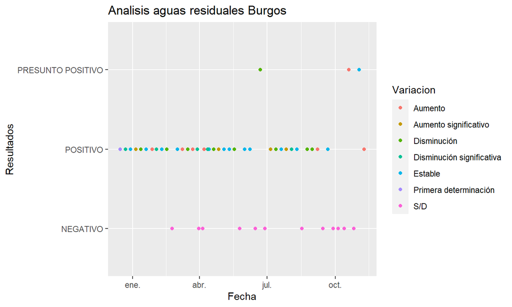

En Burgos, observamos tambien como se ha detectado de manera regular la presencia de COVID-19. En este caso, si que observamos una mayor variacion en los valores, ya que aumentan y disminuyen constantemente.

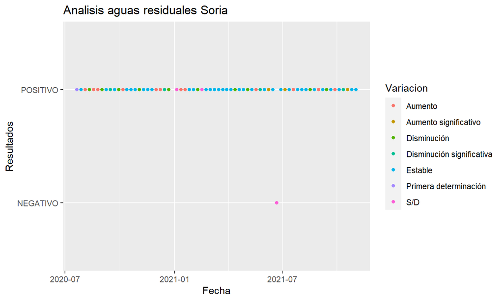

En Soria observamos como se ha detectado el COVID-19 constantemente durante todo el año, con solo un valor negativo. Tambien observasmos que el valor se mantiene constante por lo general.

## OBJETIVO 3

[figure not shown]

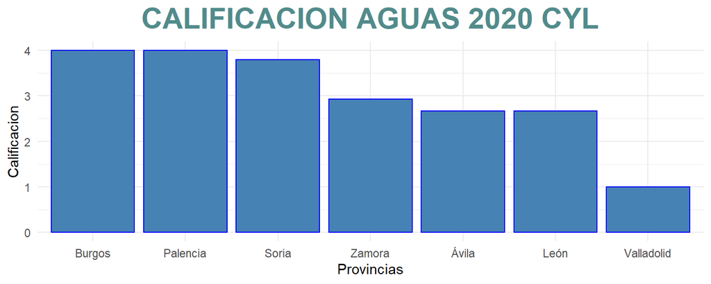

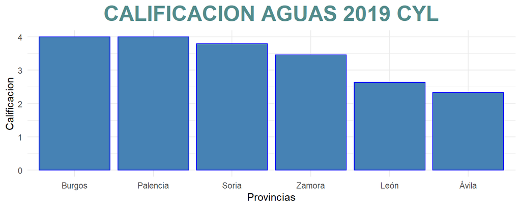

[figure not shown]